# Wages and profits in GVA

Working note: how GVA splits between pay and profit across industries, supply chains, countries and places, with new UK and US calculations

Author

Drafted by Claude Code (Claude Opus 5.5) for Dan Olner

Published

29 October 2026

## What this is

This note shows the outputs of the scripts in code/wage_profit_shares, alongside the main points of the longer write-up, wage_profit_shares_gva.md. The write-up has the full literature review, all the sources and the caveats. This note keeps to the headlines and the charts.

The question: what do we know, empirically, about how GVA splits between wages and profits, and how that varies within and across sectors, supply chains, countries and places?

The calculations are new, made with five public datasets:

- ONS’s chart data from its [November 2024 labour share article](https://www.ons.gov.uk/economy/economicoutputandproductivity/output/articles/trendsintheuklabourshare1997to2023/2024-11-25);
- ONS’s [2023 input–output analytical tables](https://www.ons.gov.uk/economy/nationalaccounts/supplyandusetables/datasets/ukinputoutputanalyticaltablesdetailed);
- ONS’s [regional GVA(B) income components](https://www.ons.gov.uk/economy/grossvalueaddedgva/datasets/nominalregionalgrossvalueaddedbalancedperheadandincomecomponents), ITL1 and ITL2 by industry, 1998–2023;
- the repo’s own ABS file, `data/abs_itl1_long.csv`, which carries standard errors;
- BEA’s [state GDP by income component](https://apps.bea.gov/regional/zip/SAGDP.zip), 1997–2025.

## Headlines

- **UK: about £1.17 of pay for every £1 of profit, or 1.5 to 1 without housing.** In 2023, compensation of employees was 53% of GVA at basic prices, and operating surplus and mixed income 46%. Owner-occupiers’ imputed rent, which no firm earns, is 10% of GVA. Taking it out, pay is 1.5 times the remaining surplus.
- **The UK labour share has risen since the mid-1990s.** ONS’s preferred measure was 59.5% in 2023, up from 53.8% in 1996. The US fell over the same period.
- **Industries differ far more than places.** Industry labour shares run from almost zero to over 80%. Excluding real estate, ITL1 regions sit between 62% and 72%.
- **Supply chains narrow the spread.** Counting every UK supplier behind each product, the spread of labour shares across products falls by 28%. Much of the capital income in labour-intensive service chains is earned by suppliers, especially landlords.
- **Regional profit shares are partly constructed.** ONS shares out regional profits with indicators, and in finance the indicator is pay. So finance’s labour share is almost identical in every region. London’s low labour share is mostly within its industries, not its industry mix. But the ABS doesn’t reproduce the regional ordering.
- **Where profits end up is a separate question.** Scotland’s GNI was 94% of its GDP in 2021, because profits flow to owners elsewhere. No English region has an equivalent estimate.

## 1. What counts as wages and profits

GVA at basic prices = compensation of employees + gross operating surplus + mixed income + taxes less subsidies on production.

Table 1: UK GVA by income component, 2023 (ONS input–output analytical tables, consistent with Blue Book 2025).

| Component | £bn | Share of GVA |
| --- | --- | --- |
| Compensation of employees | 1,330 | 53.2% |
| Gross operating surplus and mixed income | 1,141 | 45.7% |
| Taxes less subsidies on production | 26 | 1.1% |
| GVA at basic prices | 2,497 | 100.0% |
| of which: owner-occupiers’ housing services | 254 | 10.2% |

Five things move the measured ratio of pay to profit by more than most real differences do:

1. **Self-employment.** Mixed income is part pay, part profit. ONS’s five ways of splitting it give 2023 labour shares from 55.1% to 63.5%. Partnerships’ profits and one-person companies’ dividends count as profit too.
2. **Housing.** Imputed rent is surplus with no workers attached.
3. **Depreciation.** Gross surplus includes capital wearing out. ONS’s net labour share was 71.5% in 2023.
4. **Taxes on production.** In GVA at basic prices but not at factor cost; about 1% of UK GVA.
5. **Operating surplus isn’t pure profit.** It pays for capital and land as well. Barkai estimates the US pure profit share rose by over 12 points while both labour and capital shares fell.

## 2. The UK over time

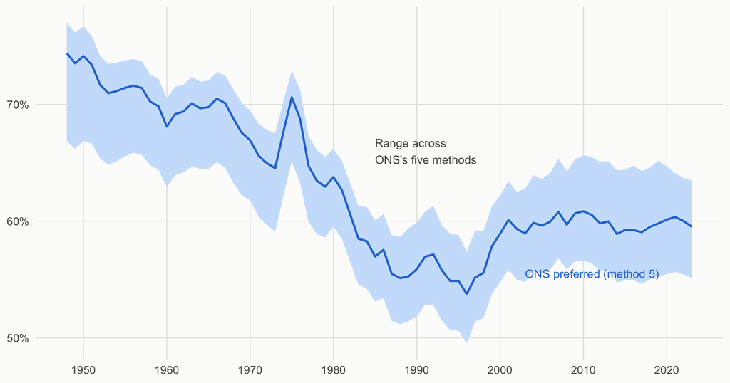

Figure 1: UK labour share, 1948–2023, % of GVA at factor cost. The band spans ONS’s five ways of treating self-employed income (method 4 starts in 1984). Source: ONS chart data, November 2024.

ONS’s preferred labour share was 68% to 74% from 1948 to the late 1960s. It fell to 53.8% in 1996, rose to 60.1% by 2001, and has stayed between 58.9% and 60.9% since. ONS links the rise to the National Minimum Wage, more graduates, a tight labour market, much higher employer pension contributions and a shift to services. It says the UK “has not experienced the decoupling between pay and productivity reported in other advanced countries”. The median worker is a different story. Teichgraeber and Van Reenen find median wages fell about 25 points behind productivity from 1981 to 2019, mostly because of rising pay inequality and pension costs.

## 3. Across industries

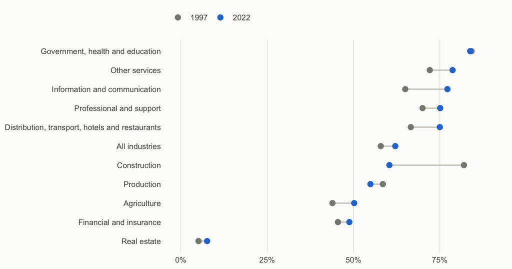

Figure 2: UK labour share by broad industry group, % of industry GVA at factor cost, 1997 and 2022. Source: ONS chart data, November 2024.

Of the 4.3 point rise in the all-industry share from 1997 to 2022, ONS attributes 2.4 points to growth in services with higher labour shares. Construction fell 21.6 points. That may reflect growth in self-employment and one-person companies, whose owners’ income counts as surplus. That’s my guess; I haven’t found an ONS explanation.

At the finer product level (next section), labour shares run from 9% (oil and gas extraction) to 87% (membership organisations). Owner-occupied housing and households as employers are excluded. Industries differ for five main reasons:

- capital intensity and resource rents (extraction, energy, water);
- property (real estate);
- self-employment (agriculture, construction, personal services);
- market power and intangibles (pharmaceuticals, alcohol and tobacco, some finance);
- public services’ output being measured by their inputs.

## 4. Within industries: firms

This section is literature only; there’s no new calculation.

- **US.** The labour share fell mainly because output moved to “superstar” firms (Autor and others) and “hyper-productive” plants (Kehrig and Vincent) with low labour shares. The typical firm’s or plant’s share didn’t fall.
- **UK manufacturing.** Valenzuela and Richiardi find the fall from 1998 to 2014 came from the representative firm, not from dispersion between firms.
- **UK markups and rent sharing.** UK average markups rose about 10% since 1997, mostly at the top of the distribution (CMA). Wages respond much less to firms’ profits after 2000 than before (Bell, Bukowski and Machin). Concentrated local labour markets pay non-unionised workers less (Abel, Tenreyro and Thwaites).

Within an industry, then, a firm’s labour share is largely the inverse of its margin. That makes it a story about demand and power as much as technology.

## 5. Along supply chains

Chain GVA is final sales minus primary and imported inputs. Prices between stages only decide who gets what, so each stage’s pay–profit split depends on bargaining at each link as well as its own technology.

For each of 105 products in the 2023 input–output table, I traced the pay and surplus earned by every UK industry behind its final sales (the Leontief inverse). I then compared that whole-chain labour share with the product’s own. Mixed income can’t be separated in these tables, so it all counts as surplus. That understates labour shares in chains with many self-employed, such as farming and construction.

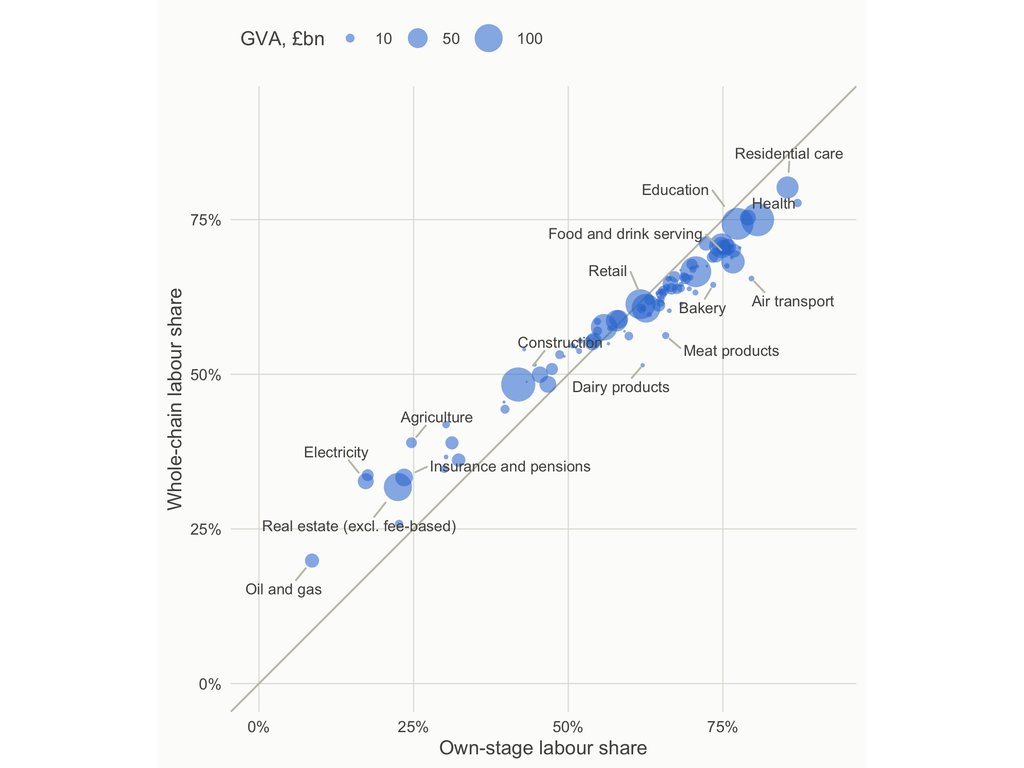

Figure 3: Labour share of each product’s own value added (x) and of all UK value added in its supply chain (y), 2023. Points on the diagonal have the same share either way. Point area shows the product’s GVA. Mixed income counts as surplus. Source: ONS input–output analytical tables, 2023; my calculation.

Table 2: Spread of labour shares across 102 products, weighted by GVA (excluding owner-occupied housing and households as employers).

| Measure | Mean | Std dev (points) | 10th pct | Median | 90th pct |
| --- | --- | --- | --- | --- | --- |
| Whole chain | 59.7% | 13.5 | 33.7% | 61.3% | 75.0% |
| Own stage | 59.9% | 18.7 | 23.5% | 63.1% | 79.0% |

Capital-heavy products (energy, extraction, agriculture) have more labour in their chains than in their own stage. Labour-intensive ones (care, health, food service, air transport) have more surplus. The chart below shows where the extra surplus comes from in six chains.

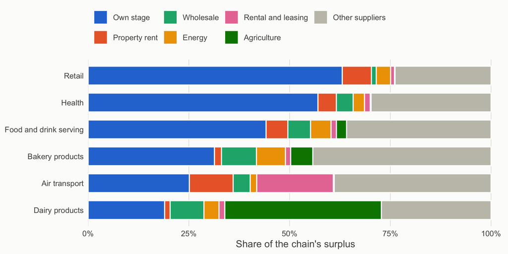

Figure 4: Where each chain’s surplus (operating surplus and mixed income) arises, 2023: at the product’s own stage, or at which suppliers. ‘Property rent’ is real estate services excluding fee-based services and owner-occupiers’ housing. Source: ONS input–output analytical tables, 2023; my calculation.

Table 3: The same shares as the chart above.

| Chain | Own stage | Property rent | Wholesale | Energy | Rental and leasing | Agriculture | Other suppliers |
| --- | --- | --- | --- | --- | --- | --- | --- |
| Retail | 63% | 7% | 1% | 4% | 1% | 0% | 24% |
| Health | 57% | 5% | 4% | 3% | 1% | 0% | 30% |
| Food and drink serving | 44% | 5% | 6% | 5% | 1% | 3% | 36% |
| Bakery products | 31% | 2% | 9% | 7% | 1% | 6% | 44% |
| Air transport | 25% | 11% | 4% | 2% | 19% | 0% | 39% |
| Dairy products | 19% | 1% | 8% | 4% | 1% | 39% | 27% |

- Retail and health keep most of their chain’s surplus at their own stage. In both, property rent is the largest supplier source.
- In air transport, three quarters of the surplus is earned by suppliers, led by aircraft leasing and property.
- In dairy and bakery, most surplus is earned upstream, much of it on farms. Farm surplus is mostly farmers’ mixed income, which is partly pay for their own work. So these chains’ labour shares are understated.

By type of final demand, ONS’s own table gives the following (household consumption looks capital-heavy because it includes imputed rent):

Table 4: Labour share of the UK value added behind each type of final demand, and its import content, 2023. Source: ONS input–output analytical tables, “Primary input from final use”.

| Final demand | Pay ÷ (pay + surplus) | Import content per £ |
| --- | --- | --- |
| Non-profit institutions | 72.1% | 5.9% |
| Government consumption | 71.4% | 10.9% |
| Services exports | 60.9% | 17.5% |
| Goods exports outside the EU | 55.8% | 29.2% |
| Investment (GFCF) | 55.2% | 14.7% |
| Goods exports to the EU | 52.2% | 28.7% |
| Household consumption | 41.7% | 11.1% |

Published chain studies point the same way:

- **US food.** Of each food dollar in 2024, 54.1 cents went to pay and 32.7 cents to property income (USDA ERS).
- **iPhone.** Apple kept 58.5% of the 2010 iPhone price as profit; Chinese labour got 1.8%.
- **Global manufacturing value chains.** Capital’s share of the value added rose from 40.9% to 47.4% between 1995 and 2008, mostly as income to intangibles (Timmer and others).

## 6. Across countries

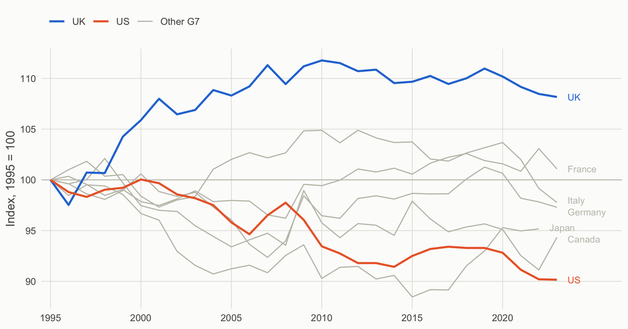

Figure 5: Labour share index for G7 countries, 1995 = 100 (ONS method 4, because several countries don’t separate operating surplus from mixed income). Source: ONS chart data, November 2024.

- **Measured gaps between countries are mostly measurement.** Raw labour shares appear to range from 5% to 80% across countries. Once self-employed income is counted, most sit between 65% and 80% (Gollin).
- **The “global decline” is mostly a US story.** Once housing and self-employment are treated the same way everywhere, most advanced economies show stable or rising labour shares (Gutiérrez and Piton). The long-run rise in the net capital share comes from housing (Rognlie).
- **Real differences remain.** These come from natural resources, where a country sits in global value chains, and where multinationals book their profits.

## 7. Geography

### 7.1 First: regional profits are shared out, not measured

ONS’s regional income components are national totals shared out by indicators. Pay follows BRES jobs × ASHE earnings. Company profits follow ABS operating surplus in most industries, but **pay** in finance and the public sector. So in those industries the regional labour share is set largely by assumption.

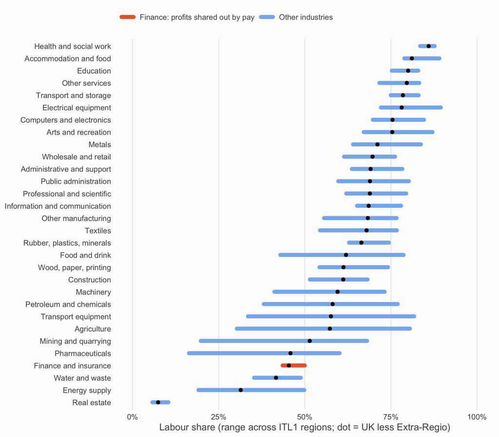

Figure 6: Range of each industry’s labour share across the 12 ITL1 regions (bar) and the value for the UK less Extra-Regio (dot), 2023, % of factor income, mixed income split as in ONS method 5. Source: ONS regional GVA(B) income components; my calculation.

Finance’s labour share runs only from 43.6% to 50.0% across regions. Most manufacturing industries, whose profits follow the ABS, have standard deviations of 5 to 13 points. In ONS’s 2009 method, profits outside manufacturing followed pay. So older regional income components showed near-uniform labour shares by construction.

### 7.2 ITL1 regions

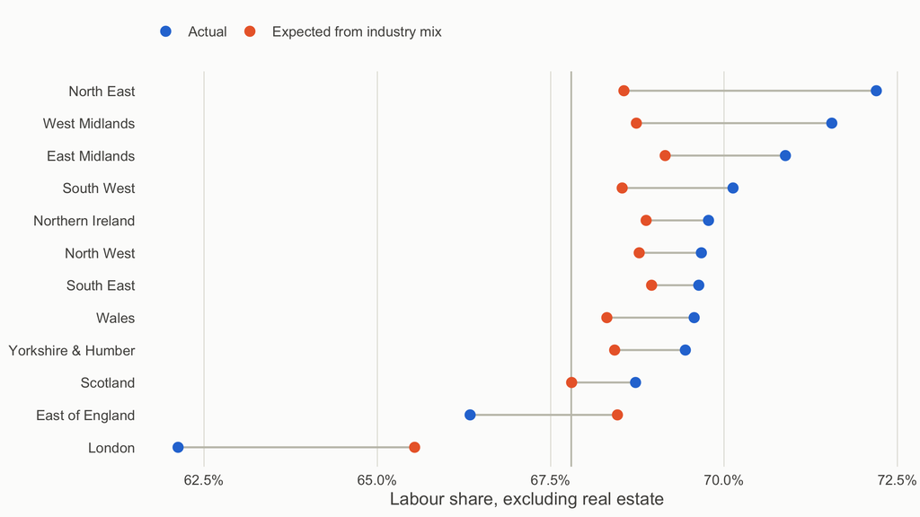

Figure 7: Labour share by ITL1 region, 2023, excluding real estate (ONS method 5): actual, and what each region’s industry mix would give at the industry labour shares of the UK less Extra-Regio. The vertical line is the UK less Extra-Regio. Source: ONS regional GVA(B) income components; my calculation.

Table 5: ITL1 labour shares, 2023 (ONS method 5).

| Region | All industries | Excl. real estate | Expected from mix | Within-industry gap (pts) | Trading profits, % of factor income |
| --- | --- | --- | --- | --- | --- |
| North East | 64.6% | 72.2% | 68.6% | +3.6 | 19.2% |
| West Midlands | 64.0% | 71.6% | 68.7% | +2.8 | 20.6% |
| East Midlands | 63.0% | 70.9% | 69.2% | +1.7 | 21.3% |
| South West | 60.5% | 70.1% | 68.5% | +1.6 | 19.9% |
| Northern Ireland | 62.2% | 69.8% | 68.9% | +0.9 | 21.9% |
| North West | 62.6% | 69.7% | 68.8% | +0.9 | 23.2% |
| South East | 60.2% | 69.6% | 69.0% | +0.7 | 21.2% |
| Wales | 62.1% | 69.6% | 68.3% | +1.3 | 21.9% |
| Yorkshire & Humber | 62.2% | 69.4% | 68.4% | +1.0 | 21.3% |
| Scotland | 61.1% | 68.7% | 67.8% | +0.9 | 21.3% |
| UK less Extra-Regio | 60.2% | 67.8% |  |  | 23.1% |
| UK (incl. Extra-Regio) | 59.6% | 66.9% |  |  | 23.9% |
| East of England | 57.6% | 66.3% | 68.5% | -2.1 | 23.8% |
| London | 56.5% | 62.1% | 65.5% | -3.4 | 27.9% |

- **London is low, mostly within industries.** London’s share is 5.7 points below that of the UK less Extra-Regio, which is what the regions add up to. Its industry mix accounts for 2.3 points of that; the rest comes from higher profit shares within its industries.
- **Which industries.** The biggest within-industry contributors are professional and scientific services, then wholesale and retail, information and communication, and administrative services.
- **Not housing.** London’s rental income share is the lowest of any region.
- **One candidate explanation.** Big law and accounting partnerships’ profits count as trading profits, though they are partly pay for partners’ work. This is my guess and isn’t checked.
- **Scotland.** Food and drink manufacturing (mostly whisky) has a much lower labour share there than in the UK as a whole.

### 7.3 ITL2 areas

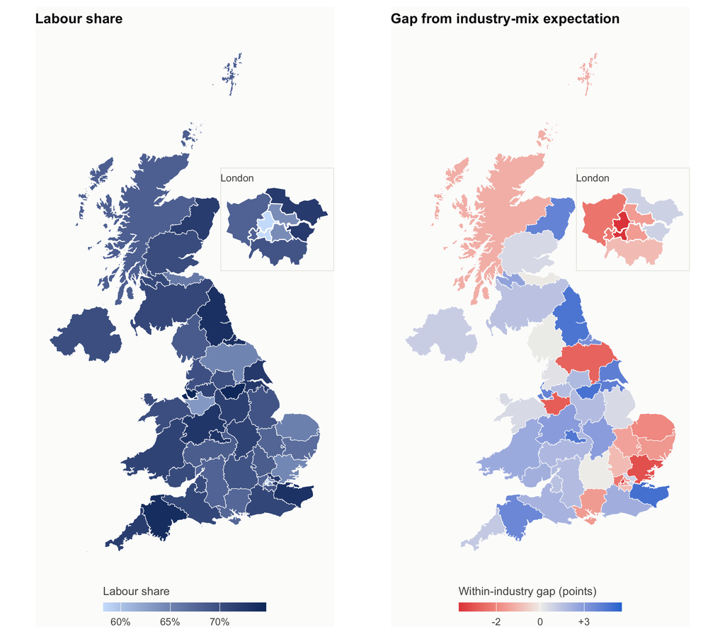

Figure 8: ITL2 areas, 2023, excluding real estate (ONS method 5). Left: labour share. Right: the within-industry gap, actual minus what the area’s industry mix would give at the industry labour shares of the UK less Extra-Regio (red = more profit than the mix suggests). Insets: London’s five ITL2 areas. Sources: ONS regional GVA(B) income components; ONS ITL2 (January 2025) boundaries; my calculation.

Table 6: ITL2 areas with the lowest and highest labour shares, 2023, excluding real estate.

|  | ITL2 area | Labour share | Expected from mix | Within-industry gap (pts) |
| --- | --- | --- | --- | --- |
| Lowest | Inner London - West | 58.2% | 62.9% | -4.6 |
| Lowest | Cheshire | 63.2% | 66.8% | -3.6 |
| Lowest | Inner London - East | 64.1% | 66.1% | -1.9 |
| Lowest | Essex | 64.7% | 68.5% | -3.9 |
| Lowest | North Yorkshire | 64.9% | 68.3% | -3.4 |
| Lowest | Norfolk | 65.2% | 67.7% | -2.4 |
| Highest | Merseyside | 74.7% | 71.4% | +3.3 |
| Highest | South Yorkshire | 74.5% | 70.6% | +4.0 |
| Highest | Devon | 73.9% | 70.7% | +3.2 |
| Highest | Northumberland, Durham, Tyne & Wear | 73.4% | 69.6% | +3.9 |
| Highest | Tees Valley | 73.3% | 70.5% | +2.9 |
| Highest | Kent | 73.3% | 69.2% | +4.0 |

Across all 46 ITL2 areas, labour shares run from 58.2% (Inner London - West) to 74.7% (Merseyside). The median is 70.1% and the standard deviation 3.3 points. Within-industry gaps vary more than industry mix (standard deviations 2.3 and 1.6 points). The highest labour shares are mostly in northern and Midlands urban areas, plus Devon and Kent. The lowest are in inner London, Cheshire, North Yorkshire and parts of the East.

### 7.4 Trends

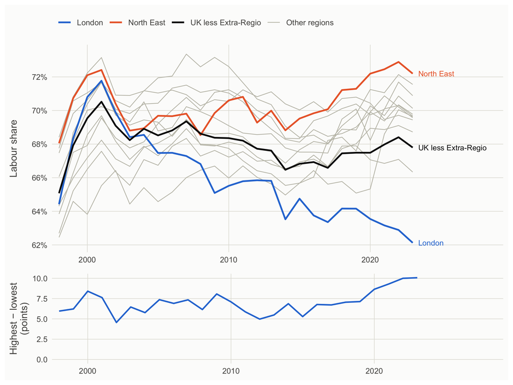

Figure 9: Top: labour share by ITL1 region, 1998–2023, excluding real estate (ONS method 5). Bottom: gap between the highest and lowest region. Source: ONS regional GVA(B) income components; my calculation.

From 1998 to 2019, the gap between the highest and lowest region ran from 4.6 to 8.4 points. Since 2020 it has been wider, reaching 10.1 points in 2023, mostly because London’s share fell. Given section 7.1, these data can’t tell whether that is real or an artefact of how profits are shared out.

### 7.5 A cross-check with the ABS

The ABS gives employment costs and aGVA for the non-financial business economy by ITL1, with standard errors. I compared its ratio with ONS’s balanced components, restricted to roughly the same industries and without a self-employment adjustment.

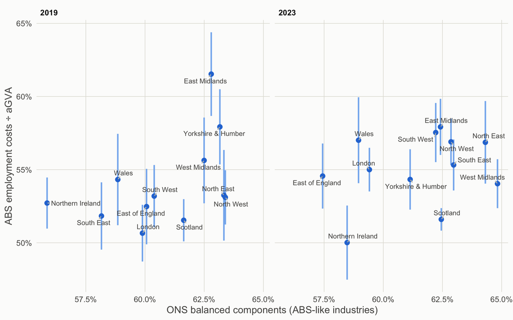

Figure 10: Labour share by ITL1 region: ONS balanced components restricted to roughly the ABS’s industries (x; compensation ÷ factor income) against ABS employment costs ÷ aGVA (y), with 95% intervals from ABS standard errors (treating the two errors as independent, so probably too wide). Sources: ONS regional GVA(B) income components; ABS 2024 edition (data/abs_itl1_long.csv); my calculation.

The two sources only weakly agree on the regional ordering: Spearman rank correlations of 0.48 in 2019 and 0.1 in 2023. Their disagreement is larger than the ABS’s own sampling error. London is lowest in the ABS in 2019 but mid-table in 2023. So the regional ordering of labour shares depends on the source and the year.

### 7.6 Where the profits go

Workplace GVA records where pay and profit arise, not who receives them.

- **Scotland.** It had a primary income deficit of 5.6% of GDP in 2021, and its GNI has been below its GDP every year since 1998. The Scottish Government points to foreign ownership (including North Sea operators), few UK headquarters in Scotland, and insurance and pension funds whose policyholders live elsewhere.
- **Ownership.** 58.8% of UK quoted shares were owned overseas at the end of 2024. Foreign-owned firms produced 28.4% of non-financial aGVA in 2020.
- **Offshore oil and gas.** Extra-Regio produced £30bn of GVA in 2023, with a labour share of about 10%. That profit isn’t placed in any region.

No English region or Wales has a GNI estimate. This is the main quantitative gap on the geography of profits.

### 7.7 Comparing with US states

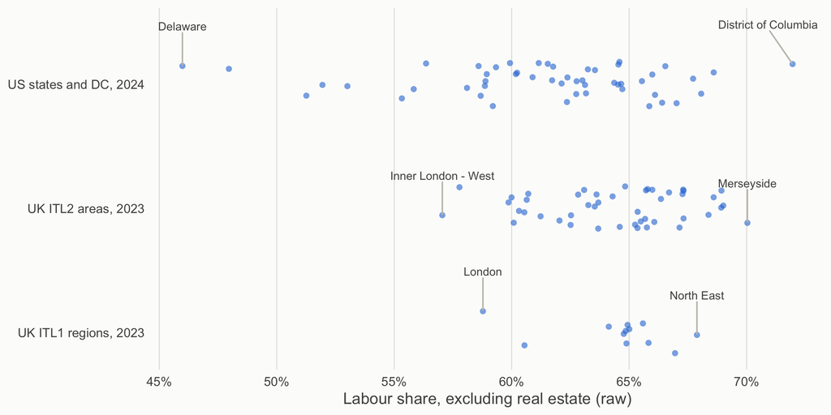

Figure 11: Spread of labour shares across US states (2024) and UK ITL2 and ITL1 areas (2023), excluding real estate. Raw shares: compensation ÷ (compensation + all other factor income, including self-employed income), so the UK points here are lower than in sections 7.2 and 7.3. Sources: BEA state GDP (SAGDP4, SAGDP7); ONS regional GVA(B) income components; my calculation.

US states vary about twice as much as UK regions. The lowest is Delaware (46.0%), with its corporate registrations and finance. The highest is District of Columbia (72.0%), with the federal government. Farm, oil and gas states sit low. Across states, the same industry’s labour share varies most in capital-heavy, profit-heavy industries: manufacturing, mining and finance. I haven’t checked how BEA shares out multi-state firms’ surplus.

The geography is still explained mainly qualitatively:

- spatial divisions of labour, with headquarters and design in core regions and routine production elsewhere (Massey);
- branch plants sending profits out of their region;
- where head offices book profits;
- buyer power over rural suppliers (Webber and Tiwasing);
- thin, concentrated local labour markets.

## 8. What this means for RegEconWorks

- **Label how each industry’s regional profits are shared out** before reading anything into a region’s pay–profit split. Finance and public services follow pay; most market industries follow the ABS regional model.
- **Report labour shares with and without real estate, and with a self-employment adjustment.** These choices move shares by more than most real differences.
- **Use the ABS as a sampling-error check, not as the truth.** The ABS and ONS disagree by more than the ABS’s error bars.
- **Use supply chains as a second lens.** Whole-chain shares show how property rent and energy feed capital income into service chains. A regional version needs multi-regional input–output tables.
- **Ask where profits go, not just where they arise.** Scotland’s GNI estimates are the model. Firm-level tax data, such as the CenTax Business-to-Worker Register, could test ONS’s regional allocation.

## Method, data and caveats

- **Full write-up.** Literature, sources and the list of things not checked are in wage_profit_shares_gva.md.
- **Code.** All numbers and charts come from the scripts in code/wage_profit_shares, sourced at the top of this document. They download raw files once into the gitignored `local/wage_profit_raw/`.
- **Labour share.** “ONS method 5” splits mixed income between pay and profit in the same proportion as the rest of each group’s factor income. “Raw” counts all mixed income as profit.
- **Whole-chain shares.** These use the Leontief inverse of the 2023 domestic input–output table, with imports excluded.
- **Industry-mix expectations.** These apply UK industry labour shares to each area’s factor-income weights, excluding real estate.
- **The regional components workbook** was downloaded on 29 October 2026 and runs from 1998 to 2023.